# [Retour à la page d’accueil](https://scortijo.github.io/2023_L3_R/)

## Formation ggplot2 - solution des exercices

> **Exercice 1:** Pouvez vous dessiner un violin plot? (indice: `?geom_violin`)

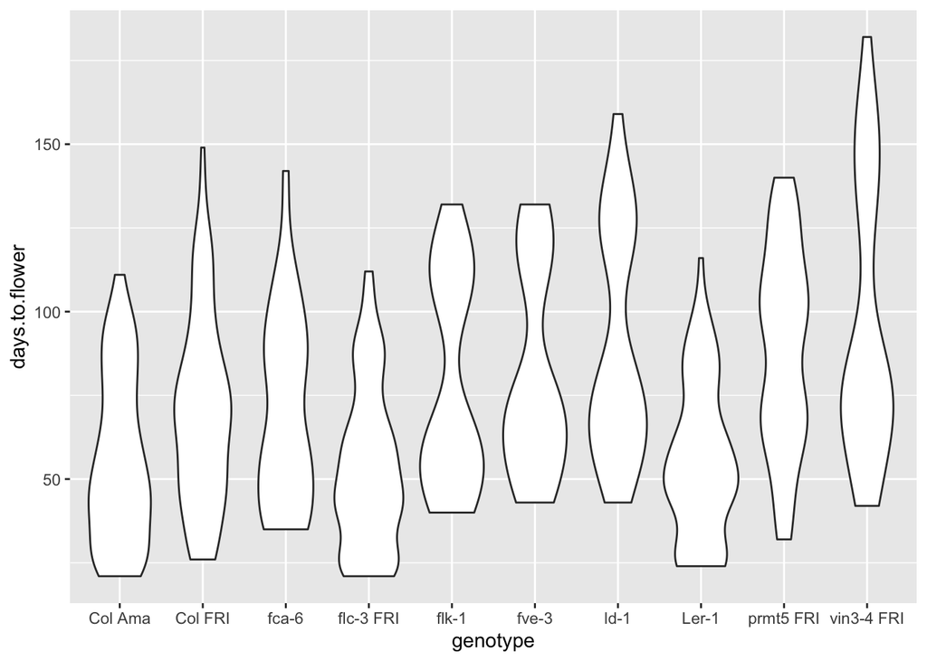

```r
ggplot(expt1, aes(genotype, days.to.flower)) +
  geom_violin()
```

> **BONUS** Quel autre type de géométrie pouvez vous utilisez avec des données de ce type (catégories et nombres)? *Aide*: Utilisez [cet arbre de décision](https://www.data-to-viz.com/) pour choisir les géométries appropriées.

```r
#Il est aussi possible d'utiliser une densité ou un histogramme
```

> **Exercice 2:** Modifiez le graphique pour que les points soient devant plutôt que derrière les boxplots.

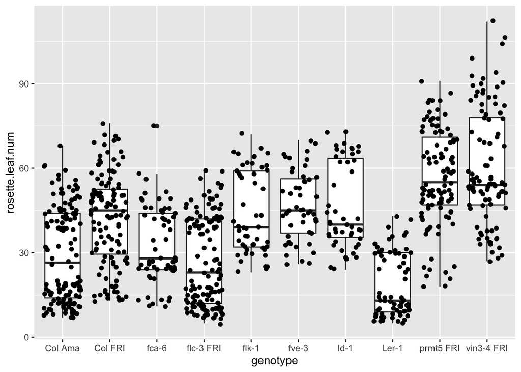

```r
ggplot(expt1, aes(genotype, rosette.leaf.num)) +
  geom_boxplot() +
  geom_jitter()
```

> **BONUS**: Ajouter la géométrie dotplot plutôt que jitter. Utilisez les exemples dans l’aide (avec ?nom de fonction) pour savoir comment l’utiliser, ou lisez [cette page de blog](http://www.sthda.com/french/wiki/ggplot2-dot-plot-guide-de-demarrage-rapide-logiciel-r-et-visualisation-de-donnees)

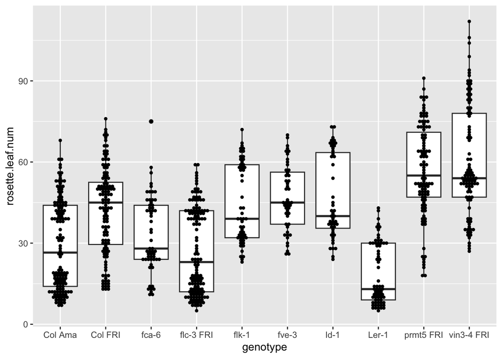

```r
ggplot(expt1, aes(genotype, rosette.leaf.num)) +
  geom_boxplot() +
  geom_dotplot(binaxis='y', stackdir='center', binwidth = 1)
```

> **Exercice 3:** Nous voulons étudier la relation entre le nombre de feuille de rosette et la longueur la limbe des feuilles (en mm) pour les génotypes.

> Pour cela, dessinez un scatter plot (`geom_point()`) entre `blade.length.mm` et `rosette.leaf.num` en colorant les points en fonction de `genotype`.

> Que se passe t-il si les points sont colorés en fonction de `days.to.bolt`?

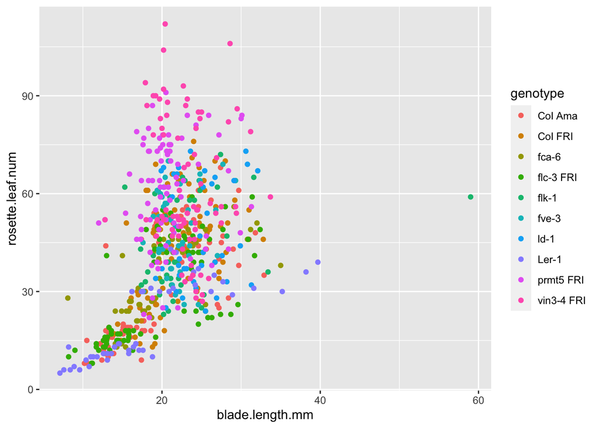

```r
ggplot(expt1, aes(blade.length.mm, rosette.leaf.num, colour = genotype)) +
  geom_point()
```

L’échelle de couleur est continue si nous utilisons `days.to.bolt` pour colorer les points car c’est une variable numérique:

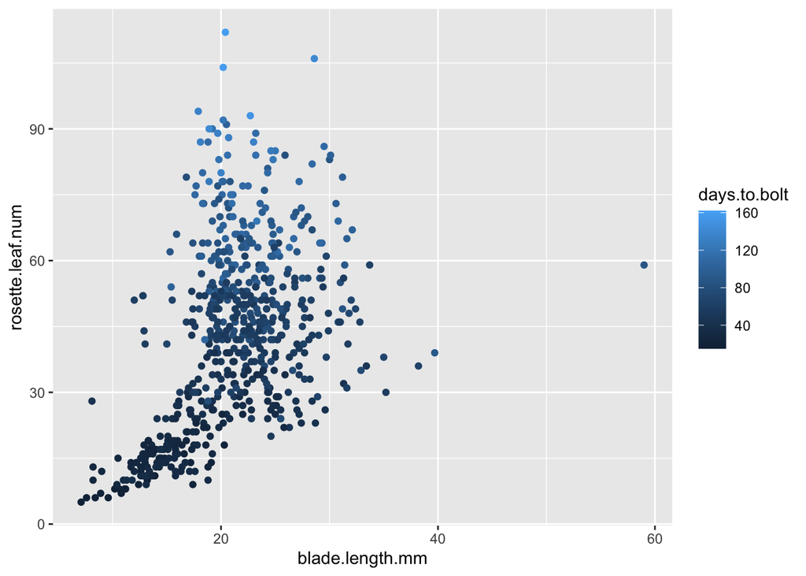

```r
ggplot(expt1, aes(blade.length.mm, rosette.leaf.num, colour = days.to.bolt)) +
  geom_point()
```

> **BONUS**: Dessinez un scatter plot (`geom_point()`) entre `blade.length.mm` et `rosette.leaf.num` en colorant les points en fonction de `vernalization`, et changez la couleur des points pour que “NV” soit en bleu et “V” soit en vert. *Aide*: Trouvez la solution en ligne (par exemple en tapant “change color points ggplot R”)

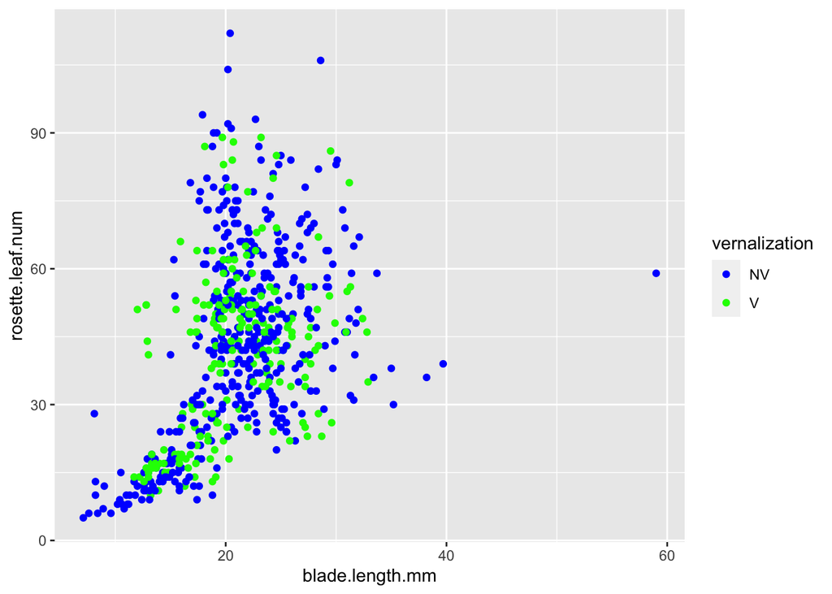

```r
ggplot(expt1, aes(blade.length.mm, rosette.leaf.num, colour = vernalization)) +
  geom_point() +
  scale_color_manual(values=c("blue","green"))
```

> **Exercice 4:** Les couleurs n’apportent plus d’information supplémentaire. Pensez à une utilisation plus intéressante des couleurs dans ce graphique.

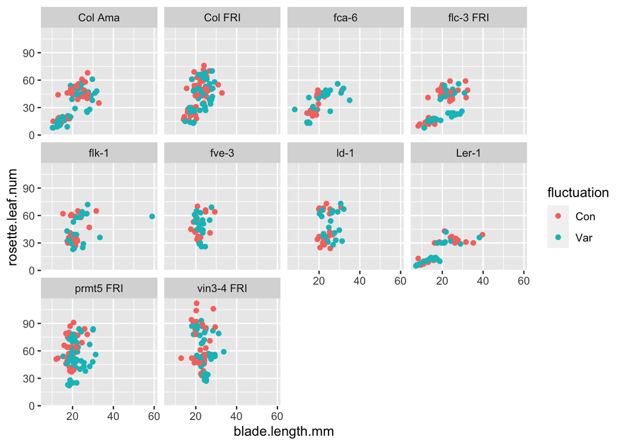

```r
ggplot(expt1, aes(blade.length.mm, rosette.leaf.num, colour = fluctuation)) +
    geom_point() +
    facet_wrap( ~ genotype)
```

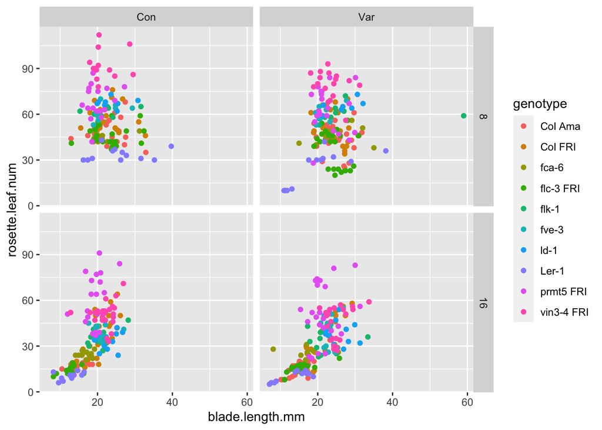

```r
ggplot(expt1, aes(blade.length.mm, rosette.leaf.num, colour = genotype)) +
    geom_point() +
    facet_grid(day.length ~ fluctuation)
```

> **Exercice 6**: Reproduisez le graphique suivant (ou quelque chose d’approchant):

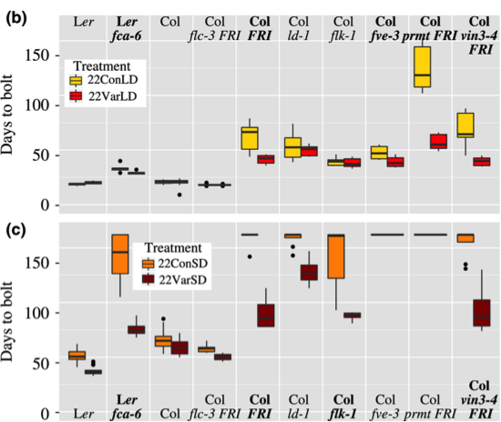

> .

> **Indice**: facet le graphique avec `day.length` et `temperature` et colorer l’intérieur des boxplot en fonction de `fluctuation`.

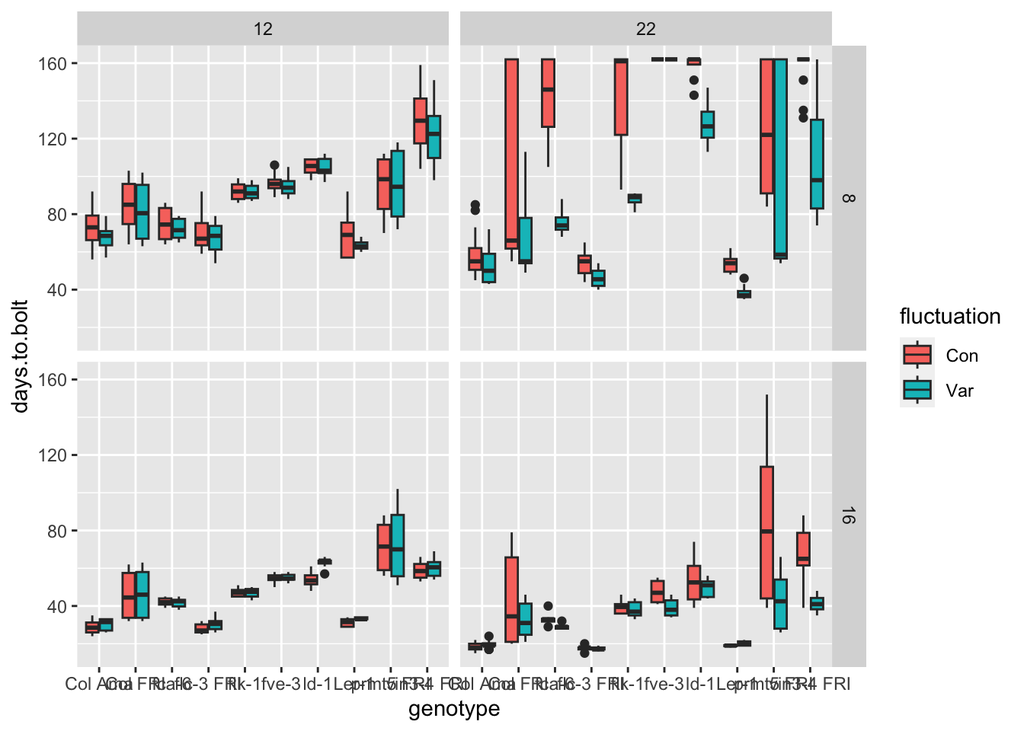

```r
ggplot(expt1, aes(genotype, days.to.bolt, fill = fluctuation)) +
    geom_boxplot() +
    facet_grid(day.length ~ temperature)
```